# Problem Statement

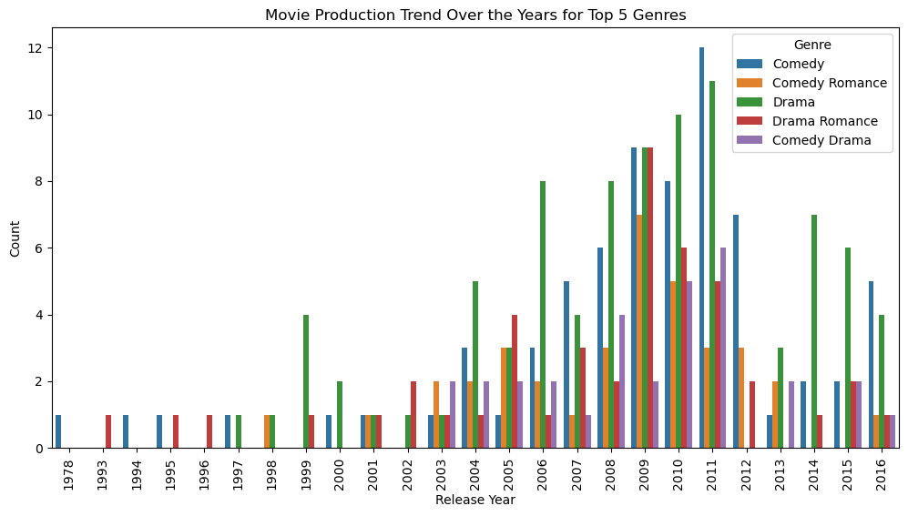

```python
# 11: How has the movie production trend evolved over the years for the top 5 genres?

top5_genres =df['genres'].value_counts().nlargest(5).index
movie_data_top5 = df[df['genres'].isin(top5_genres)]
plt.figure(figsize=(12, 6))
sns.countplot(x='release_ year', hue='genres', data=movie_data_top5, palette='tab10')
plt.title('Movie Production Trend Over the Years for Top 5 Genres')
plt.xlabel('Release Year')
plt.ylabel('Count')
plt.xticks(rotation=90)
plt.legend(title='Genre')
plt.show()
```

- The countplot demonstrates that some genres have experienced variations in production from year to year, with certain years witnessing higher production counts for specific genres.

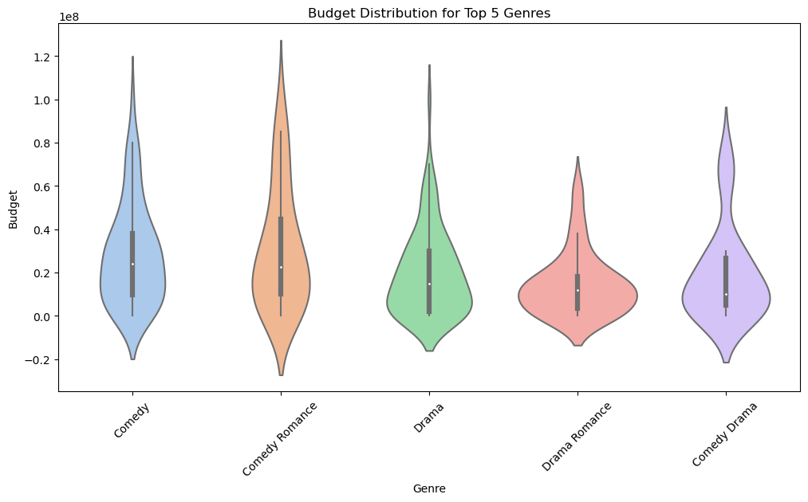

```python
# 12. What is the distribution of movie budgets for the top 5 genres?
plt.figure(figsize=(12, 6))
sns.violinplot(x='genres', y='budget', data=movie_data_top5, palette='pastel')
plt.title('Budget Distribution for Top 5 Genres')
plt.xlabel('Genre')
plt.ylabel('Budget')
plt.xticks(rotation=45)
plt.show()
```

- The violin plot provides a compact summary of how budgets differ within these genres, highlighting the range and density of budget values for each genre.

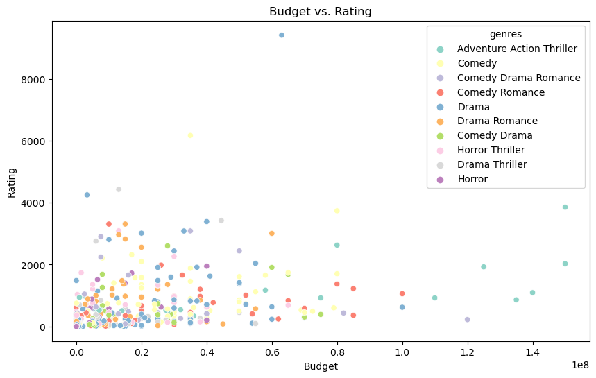

```python
# 13. How does the movie budget correlate with the movie rating?
top_10_genres = df['genres'].value_counts().head(10).index
filtered_data = df[df['genres'].isin(top_10_genres)]
plt.figure(figsize=(10, 6))
sns.scatterplot(x='budget', y='vote_count', data=filtered_data, hue='genres', palette='Set3')
plt.title('Budget vs. Rating')
plt.xlabel('Budget')
plt.ylabel('Rating')
plt.show()
```

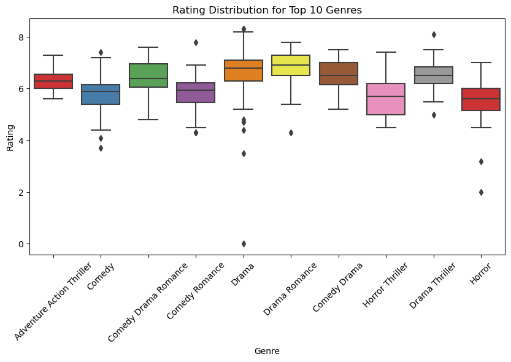

```python
# 14. What is the distribution of movie ratings for the top 10 genres?
top_10_genres = df['genres'].value_counts().head(10).index
filtered_data = df[df['genres'].isin(top_10_genres)]
plt.figure(figsize=(10, 5))
sns.boxplot(x='genres', y='vote_average', data=filtered_data, palette='Set1')
plt.title('Rating Distribution for Top 10 Genres')
plt.xlabel('Genre')
plt.ylabel('Rating')
plt.xticks(rotation=45)
plt.show()
```

- The boxplot shows a clear summary of how ratings differ within different genres, highlighting the range, median, and potential outliers in each genre's ratings distribution.

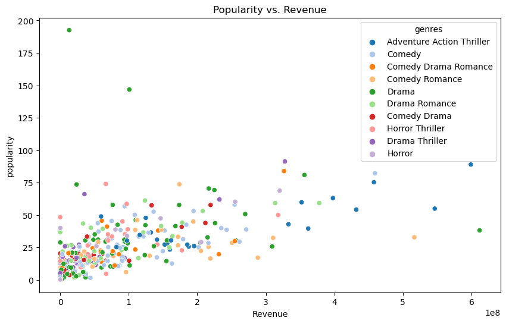

```python
# 15. How does the popularity vary with movie revenue?
top_10_genres = df['genres'].value_counts().head(10).index
filtered_data = df[df['genres'].isin(top_10_genres)]
plt.figure(figsize=(10, 6))
sns.scatterplot(x='revenue', y='popularity', data=filtered_data, hue='genres', palette='tab20')
plt.title('Popularity vs. Revenue')
plt.xlabel('Revenue')
plt.ylabel('popularity')
plt.show()
```

- The scatterplot shows that there is a positive correlation between popularity and revenue across these genres. It suggests that movies with higher revenues tend to be more popular.